# Apply rate: Prediction Models

Xiangyu Liu

2018/3/24

# 1 Research Data

## 1.1 *R* Libraries

The research uses the libraries loaded below:

```r
library(knitr)
library(dplyr)
library(gridExtra)
```

```r
library(ggplot2)
library(ggthemes)
library(cowplot)
library(moments)
library(caret)
library(glmnet)
library(pscl)
library(ROCR)
library(class)
library(gbm)
library(pROC)
```

## 1.2 Importing Glassdoor data sets and splitting into the traning set and test set

```r
allSet <- read.csv("ozan_p_pApply_intern_challenge_03_20_min.csv", stringsAsFactors = F)
train <- allSet[allSet$search_date_pacific != '2018-01-27',]
train <- train[-c(9,10,11)]
test <- allSet[allSet$search_date_pacific == '2018-01-27',]
test <- test[-c(9,10,11)]
```

## 1.3 Data dimensions and structure

```r
trainDim <- dim(train)
testDim <- dim(test)
trainR <- trainDim[1];testR <- testDim[1]
trainC <- trainDim[2];testC <- testDim[2]
```

By having a look at the dimensions of the train and test data, we see that they have **1084364** and **116526** observations (houses) and **8** and **8** features, respectively.

```r
glimpse(allSet)
```

```
## Observations: 1,200,890
## Variables: 11
## $ title_proximity_tfidf       <dbl> 0.000000, 0.000000, 0.000000, 11.9...
## $ description_proximity_tfidf <dbl> 0.19837657, 0.00000000, 0.00000000...
## $ main_query_tfidf            <dbl> 0.0000000, 9.3085520, 9.3085520, 3...
## $ query_jl_score              <dbl> 0.022545460, 0.005782444, 0.005782...
## $ query_title_score           <dbl> 1.470588e-02, 3.020060e-06, 3.0200...
## $ city_match                  <dbl> 1, -1, -1, 0, 1, 1, -1, 1, 1, 1, 1...
## $ job_age_days                <dbl> 16, 0, 0, 23, 0, 1, 20, 1, 1, 0, 0...
## $ apply                       <int> 0, 0, 0, 0, 0, 0, 0, 0, 0, 0, 0, 0...
## $ search_date_pacific         <chr> "2018-01-24", "2018-01-24", "2018-...
## $ u_id                        <chr> "5f42afe6-e7d0-4822-b95e-57ae0682f...
## $ mgoc_id                     <int> 10148, 10016, 10016, 10039, -1, 10...
```

We can also have a glimpse of the data structure. It is clear that we have features that are doubles and characters. It’s worth noticing that the outcome variable (*apply*) is integer.

## 1.4 Data dictionary

Below is a description of each of the features existing in the data sets to give insight of what information we have about users.

| Feature | Description |
| --- | --- |
| title proximity tfidf | Measures the closeness of query and job title. |
| description proximity tfidf | Measures the closeness of query and job description. |
| main query tfidf | A score related to user query closeness to job title and job description. |
| query jl score | Measures the popularity of query and job listing pair. |
| query title score | Measures the popularity of query and job title pair. |
| city match | Indicates if the job listing matches to user (or, user-specified) location. |
| job age days | Indicates the age of job listing posted. |

# 2 Data Cleaning

## 2.1 Imputing missing values

Missing values in data sets are problematic in data analysis, model training and prediction. Hence, we will impute missing values before going further in model training.

Let’s first check for missing values

```r
sapply(train,function(x) sum(is.na(x)))
```

```
##       title_proximity_tfidf description_proximity_tfidf
##                           0                           0
##            main_query_tfidf              query_jl_score
##                           0                           0
##           query_title_score                  city_match
##                           0                           0
##                job_age_days                       apply
##                           0                           0
```

Great! There are no missing values in our dataset.

# 3 Feature Engineering

*Feature Engineering* simply refers to creating new features from the existing ones to improve model performance. It would make training the model possible, easier, and more accurate in prediction.

## 3.1 Log transformation

It is a good practice to transform highly skewed numerical variables into their log values. This helps show the relative change in variable values rather than the absolute change for variables not showing normal distribution. Most researchers use the range of -2 to +2 as the acceptable limits of skewness to decide on a variable normality. Hence, we will use this range to log transform values.

```r
# create a new copy of the master data set (allSet)
allSetNew <- allSet[-c(8:11)]

# get classes of features in the data set
featureClasses <- sapply(names(allSetNew[]), function(x){class(allSetNew[[x]])})

featureClasses
```

```
##       title_proximity_tfidf description_proximity_tfidf
##                   "numeric"                   "numeric"
##            main_query_tfidf              query_jl_score
##                   "numeric"                   "numeric"
##           query_title_score                  city_match
##                   "numeric"                   "numeric"
##                job_age_days
##                   "numeric"
```

```r
# get numeric or integer class features
numFeatures <- names(featureClasses[featureClasses == "numeric" | featureClasses == "integer"])

# get character class features
charFeatures <- names(featureClasses[featureClasses == "character"])

# determine skewness of each numeric feature
skewedVals <- sapply(numFeatures, function(x){skewness(allSetNew[[x]],na.rm = T)})

# identify skewed features with threshold of -2,+2
skewedFeatures <- skewedVals[skewedVals < -2 | skewedVals > 2]

# log-transform skewed features
for (i in names(skewedFeatures)) {
        allSet[[i]] <- log(allSet[[i]] + 1)
}
```

# 4 Model Training and Testing

Now, having all features processed and engineered, we can start the model training then testing with all existing features (except the *Id*) as model predictors.

First, we will re-split the full data set into its original *train* and *test* sets.

```r
train <- allSet[allSet$search_date_pacific != '2018-01-27',]
train <- train[-c(9,10,11)]
test <- allSet[allSet$search_date_pacific == '2018-01-27',]
test <- test[-c(9,10,11)]
```

## 4.1 Logistic Regression Model

The goal of logistic regression is to describe the relationship between the dichotomous characteristic of interest and a set of independent variables. Logistic regression generates the coefficients (and its standard errors and significance levels) of a formula to predict a logit transformation of the probability of presence of the characteristic of interest.

```r
model <- glm(apply ~.,family=binomial(link='logit'),data=train)
summary(model)
```

```
##
## Call:
## glm(formula = apply ~ ., family = binomial(link = "logit"), data = train)
##
## Deviance Residuals:
##     Min       1Q   Median       3Q      Max
## -1.1589  -0.4447  -0.4160  -0.3880   2.4906
##
## Coefficients:
##                               Estimate Std. Error  z value Pr(>|z|)
## (Intercept)                 -2.5285118  0.0086383 -292.710   <2e-16 ***
## title_proximity_tfidf        0.0074204  0.0004925   15.066   <2e-16 ***
## description_proximity_tfidf -0.0675774  0.0221659   -3.049   0.0023 **
## main_query_tfidf             0.0348155  0.0020160   17.270   <2e-16 ***
## query_jl_score              10.7417395  0.2843338   37.779   <2e-16 ***
## query_title_score            2.1897696  0.0761726   28.747   <2e-16 ***
## city_match                   0.0525947  0.0045960   11.444   <2e-16 ***
## job_age_days                -0.0913329  0.0033057  -27.629   <2e-16 ***
## ---
## Signif. codes:  0 '***' 0.001 '**' 0.01 '*' 0.05 '.' 0.1 ' ' 1
##
## (Dispersion parameter for binomial family taken to be 1)
##
##     Null deviance: 655309  on 1084363  degrees of freedom
## Residual deviance: 648786  on 1084356  degrees of freedom
## AIC: 648802
##
## Number of Fisher Scoring iterations: 5
```

Now I can analyze the fitting and interpret what the model is telling us.

First of all, according to the regression results, most of the variables are highly significant (***), except for description_proximity_tfidf. It suggests a strong association of these variables with the probability of applying.

Secondly, we can find whether the variable has a positive or negative impact on the dependent variable. For example, query_jl_score and query_title_score would enhance the probability of applying, while job_age_days reduces the probability of applying.

Then I decide to run the anova() function on the model to analyze the table of deviance.

```r
anova(model, test="Chisq")
```

```
## Analysis of Deviance Table
##
## Model: binomial, link: logit
##
## Response: apply
##
## Terms added sequentially (first to last)
##
##
##                             Df Deviance Resid. Df Resid. Dev  Pr(>Chi)
## NULL                                      1084363     655309
## title_proximity_tfidf        1  2683.99   1084362     652625 < 2.2e-16 ***
## description_proximity_tfidf  1    25.34   1084361     652599 4.796e-07 ***
## main_query_tfidf             1    40.02   1084360     652559 2.509e-10 ***
## query_jl_score               1  2157.30   1084359     650402 < 2.2e-16 ***
## query_title_score            1   753.20   1084358     649649 < 2.2e-16 ***
## city_match                   1    99.95   1084357     649549 < 2.2e-16 ***
## job_age_days                 1   763.05   1084356     648786 < 2.2e-16 ***
## ---
## Signif. codes:  0 '***' 0.001 '**' 0.01 '*' 0.05 '.' 0.1 ' ' 1
```

```r
fitted.results <- predict(model,newdata=subset(test,select=c(1,2,3,4,5,6,7)),type='response')

fitted.results <- ifelse(fitted.results > 0.5,1,0)

misClasificError<-table(fitted.results != test$apply)['TRUE']/nrow(test)

print(paste('Accuracy of Logistic Regression',1-misClasificError))
```

```
## [1] "Accuracy of Logistic Regression 0.909153322005389"
```

The 90.91% accuracy on the test set is quite a good result. However, this result is somewhat dependent on the split of the data that I made earlier, therefore for a more precise score, I would be better off running some kind of cross validation such as k-fold cross validation for the next time.

As a last step, I am going to plot the ROC curve and calculate the AUC (area under the curve) which are typical performance measurements for a binary classifier. The ROC is a curve generated by plotting the true positive rate (TPR) against the false positive rate (FPR) at various threshold settings while the AUC is the area under the ROC curve. As a rule of thumb, a model with good predictive ability should have an AUC closer to 1 (1 is ideal) than to 0.5.

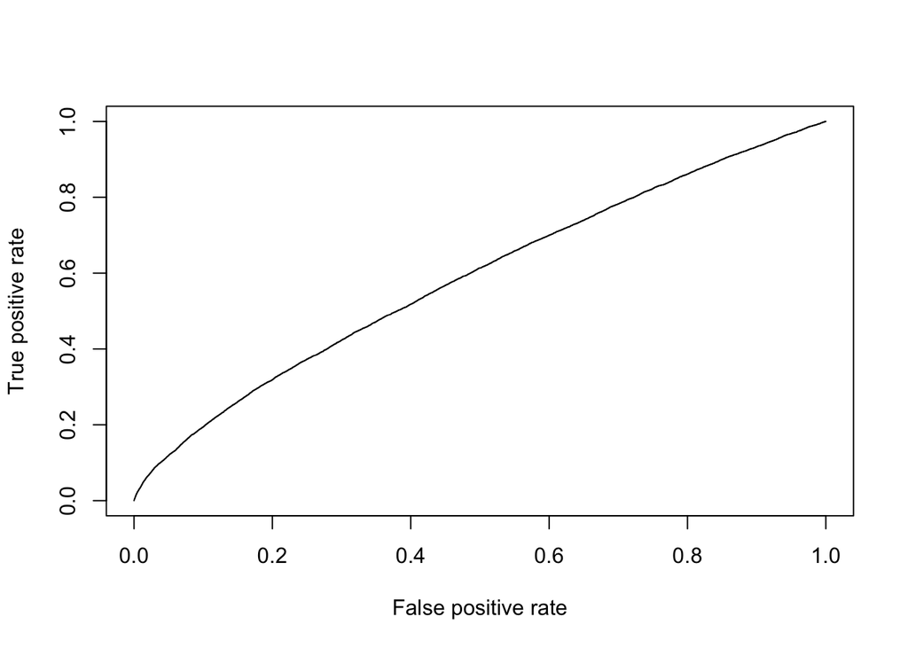

```r
p <- predict(model, newdata=subset(test, type="response"))
pr <- prediction(p, test$apply)
prf <- performance(pr, measure = "tpr", x.measure = "fpr")

plot(prf)
```

```r
auc <- performance(pr, measure = "auc")
auc <- auc@y.values[[1]]
auc
```

```
## [1] 0.5871295
```

The AUC is 0.5871295 here, which is not as good as I expect. So, let’s try other models next!

## 4.2 gbm model

Then let’s try to use the gradient boosting model. For GBM, CART is used and XGBoost also utilizes an algorithm similar to CART.

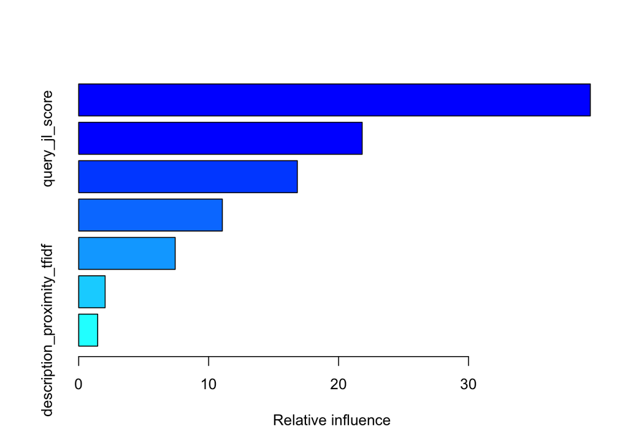

```
##                                                     var   rel.inf
## query_title_score                     query_title_score 39.374311
## query_jl_score                           query_jl_score 21.818344
## title_proximity_tfidf             title_proximity_tfidf 16.829345
## main_query_tfidf                       main_query_tfidf 11.054191
## job_age_days                               job_age_days  7.426056
## city_match                                   city_match  2.035023
## description_proximity_tfidf description_proximity_tfidf  1.462730
```

```r
# save the outcome for the gbm model
tempOutcome <- allSet$apply

# generalize outcome and predictor variables
outcomeName <- 'apply'
predictorsNames <- names(train)[names(train) != outcomeName]
train1<-train
test1<-test
train1$apply <- ifelse(train1$apply==1,'yes','nope')
test1$apply <- ifelse(test1$apply==1,'yes','nope')

# create caret trainControl object to control the number of cross-validations performed
objControl <- trainControl(method='cv', number=3, returnResamp='none', summaryFunction = twoClassSummary, classProbs = TRUE)


# run model
objModel <- train(train1[,predictorsNames], as.factor(train1[,outcomeName]),
                  method='gbm',
                  trControl=objControl,
                  metric = "ROC",
                  preProc = c("center", "scale"))
summary(objModel)
```

```r
print(objModel)
```

```
## Stochastic Gradient Boosting
##
## 1084364 samples
##       7 predictor
##       2 classes: 'nope', 'yes'
##
## Pre-processing: centered (7), scaled (7)
## Resampling: Cross-Validated (3 fold)
## Summary of sample sizes: 722909, 722910, 722909
## Resampling results across tuning parameters:
##
##   interaction.depth  n.trees  ROC        Sens      Spec
##   1                   50      0.5815891  1.000000  0.000000e+00
##   1                  100      0.5836083  1.000000  0.000000e+00
##   1                  150      0.5844849  1.000000  0.000000e+00
##   2                   50      0.5849142  1.000000  0.000000e+00
##   2                  100      0.5874888  1.000000  0.000000e+00
##   2                  150      0.5892715  0.999997  1.026525e-05
##   3                   50      0.5866252  1.000000  0.000000e+00
##   3                  100      0.5896558  1.000000  0.000000e+00
##   3                  150      0.5910680  0.999997  1.026525e-05
##
## Tuning parameter 'shrinkage' was held constant at a value of 0.1
##
## Tuning parameter 'n.minobsinnode' was held constant at a value of 10
## ROC was used to select the optimal model using the largest value.
## The final values used for the model were n.trees = 150,
##  interaction.depth = 3, shrinkage = 0.1 and n.minobsinnode = 10.
```

We now call the predict function and pass it our trained model and our testing data. Let’s start by looking at class predictions and using the caret postResample function to get an accuracy score:

```r
predictions <- predict(object=objModel, test1[,predictorsNames], type='raw')
print(postResample(pred=predictions, obs=as.factor(test1[,outcomeName])))
```

```
##  Accuracy     Kappa
## 0.9091533 0.0000000
```

The accuracy rate of gbm model is 90.91%. Now let’s look at probabilities:

```r
predictions <- predict(object=objModel, test1[,predictorsNames], type='prob')
head(predictions)
```

```
##        nope        yes
## 1 0.8836075 0.11639251
## 2 0.9134635 0.08653654
## 3 0.8309216 0.16907840
## 4 0.8980954 0.10190455
## 5 0.9236657 0.07633431
## 6 0.9390207 0.06097935
```

To get the AUC score, we need to pass the yes column to the roc function:

```r
auc <- roc(ifelse(test1[,outcomeName]=="yes",1,0), predictions[[2]])
auc
```

```
##
## Call:
## roc.default(response = ifelse(test1[, outcomeName] == "yes",     1, 0), predictor = predictions[[2]])
##
## Data: predictions[[2]] in 105940 controls (ifelse(test1[, outcomeName] == "yes", 1, 0) 0) < 10586 cases (ifelse(test1[, outcomeName] == "yes", 1, 0) 1).
## Area under the curve: 0.6042
```

```r
print(auc$auc)
```

```
## Area under the curve: 0.6042
```

We can also call the caret function varImp to figure out the variables that were important to the model.

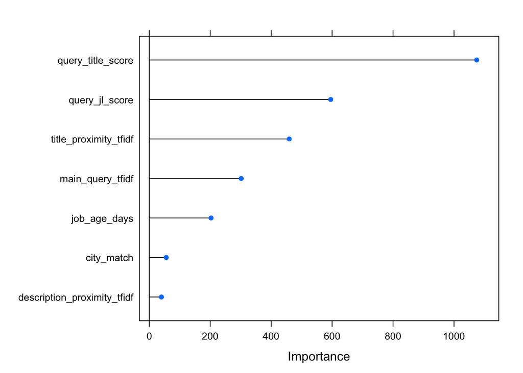

```r
plot(varImp(objModel,scale=F))
```

# 5 Subset the whole dataset according to the class of job titles

## 5.1 Choose one typical class of job title

```r
unique(allSet$mgoc_id)
```

```
##   [1] 10148 10016 10039    -1 10058 10132 10103 10047 10146 10083 10048
##  [12] 10066 10089 10060 10085 10055 10013 10111 10151 10057 10028 10064
##  [23] 10107 10145 10157 10152 10006 10122 10084 10018 10012 10140 10131
##  [34] 10009 10124 10120 10036 10003 10118 10082 10116 10074 10068 10007
##  [45] 10025 10138 10097 10019 10002 10033 10119 10005 10126 10091 10027
##  [56] 10108 10049 10081 10014 10153 10133 10045 10037 10023 10046 10092
##  [67] 10094 10128 10137 10052 10031 10114 10154 10024 10141 10090 10061
##  [78] 10127 10075 10102 10121 10130 10017 10040 10093 10029 10115 10042
##  [89] 10053 10139 10050 10096 10041 10020 10022 10070 10099 10078 10072
## [100] 10106 10135 10076 10079 10080 10144 10034 10129 10004 10149 10104
## [111] 10059 10136 10056 10021 10051 10001 10100 10077 10117 10105 10010
## [122] 10069 10134 10087 10109 10073 10011 10015 10123 10112 10030 10067
## [133] 10086 10035 10071 10044 10101 10095 10110 10088 10038 10113 10125
## [144] 10043 10063 10065 10155 10150 10008 10098 10026 10032 10143 10156
## [155] 10062 10147 10142
```

There are 157 unique classes of job titles in all. Then let’s choose one class as an example.

## 5.2 Resplit the data

```r
allSetClass <- allSet[allSet$mgoc_id == 10148,]
train_class <- allSetClass[allSetClass$mgoc_id == 10148,]
train_class <- train_class[-c(9,10,11)]
test_class <- allSetClass[allSetClass$search_date_pacific == '2018-01-27',]
test_class <- test_class[-c(9,10,11)]
```

# 6 Redo the model training and testing

## 6.1 Rerun the logistic model

```r
model_class <- glm(apply ~.,family=binomial(link='logit'),data=train_class)
summary(model_class)
```

```
##
## Call:
## glm(formula = apply ~ ., family = binomial(link = "logit"), data = train_class)
##
## Deviance Residuals:
##     Min       1Q   Median       3Q      Max
## -0.8619  -0.4357  -0.4103  -0.3852   2.4583
##
## Coefficients:
##                              Estimate Std. Error z value Pr(>|z|)
## (Intercept)                 -2.355377   0.141945 -16.594  < 2e-16 ***
## title_proximity_tfidf       -0.012202   0.007823  -1.560  0.11879
## description_proximity_tfidf -0.487108   0.408064  -1.194  0.23259
## main_query_tfidf             0.083554   0.032310   2.586  0.00971 **
## query_jl_score              -3.251811   5.478954  -0.594  0.55284
## query_title_score            3.555587   1.417225   2.509  0.01211 *
## city_match                   0.116111   0.073776   1.574  0.11553
## job_age_days                -0.085257   0.049790  -1.712  0.08684 .
## ---
## Signif. codes:  0 '***' 0.001 '**' 0.01 '*' 0.05 '.' 0.1 ' ' 1
##
## (Dispersion parameter for binomial family taken to be 1)
##
##     Null deviance: 2945.4  on 5102  degrees of freedom
## Residual deviance: 2929.1  on 5095  degrees of freedom
## AIC: 2945.1
##
## Number of Fisher Scoring iterations: 5
```

```r
fitted.results2 <- predict(model_class,newdata=subset(test,select=c(1,2,3,4,5,6,7)),type='response')

fitted.results2 <- ifelse(fitted.results > 0.5,1,0)

misClasificError2<-table(fitted.results != test$apply)['TRUE']/nrow(test)

print(paste('Accuracy of Logistic Regression',1-misClasificError2))
```

```
## [1] "Accuracy of Logistic Regression 0.909153322005389"
```

The accuracy rate of new logistic regression model is 90.91%, which is same with the accuracy of original logistic regression model.

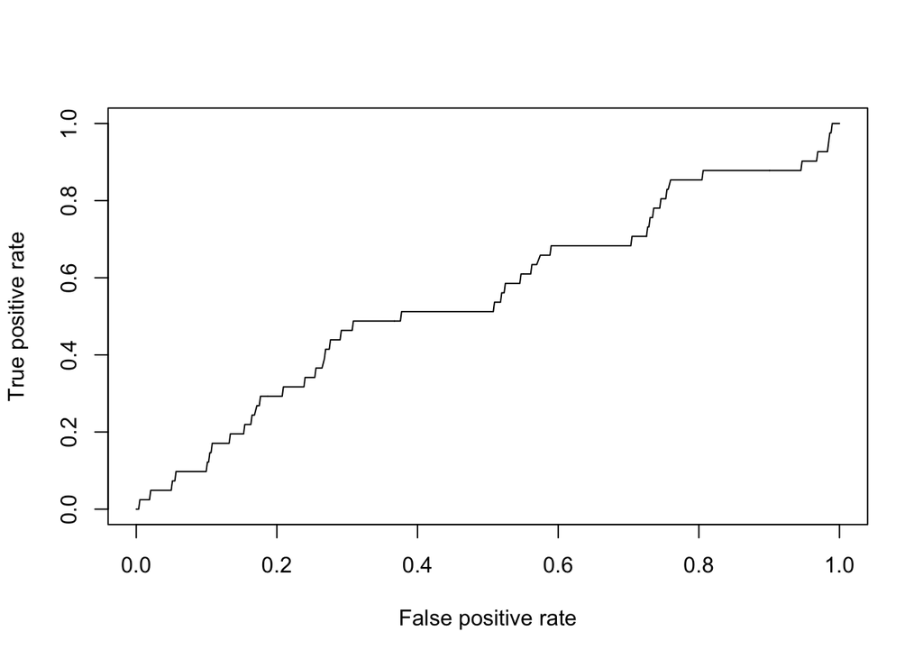

```r
p <- predict(model_class, newdata=subset(test_class, type="response"))
pr <- prediction(p, test_class$apply)
prf <- performance(pr, measure = "tpr", x.measure = "fpr")

plot(prf)
```

```r
auc <- performance(pr, measure = "auc")
auc <- auc@y.values[[1]]
auc
```

```
## [1] 0.5518136
```

The AUC is 0.5518136 here, which is lower than the AUC of the original logistic regression model.

## 6.2 Rerun the gbm model

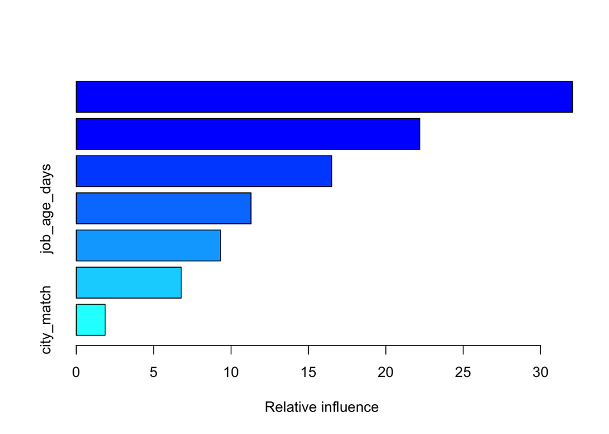

```
##                                                     var   rel.inf
## query_title_score                     query_title_score 32.059752
## query_jl_score                           query_jl_score 22.192560
## main_query_tfidf                       main_query_tfidf 16.498036
## job_age_days                               job_age_days 11.286134
## description_proximity_tfidf description_proximity_tfidf  9.324063
## title_proximity_tfidf             title_proximity_tfidf  6.777036
## city_match                                   city_match  1.862419
```

```r
train_class$apply <- ifelse(train_class$apply==1,'yes','nope')
test_class$apply <- ifelse(test_class$apply==1,'yes','nope')


# run model
objModel <- train(train_class[,predictorsNames], as.factor(train_class[,outcomeName]),
                  method='gbm',
                  trControl=objControl,
                  metric = "ROC",
                  preProc = c("center", "scale"))
summary(objModel)
```

```r
print(objModel)
```

```
## Stochastic Gradient Boosting
##
## 5103 samples
##    7 predictor
##    2 classes: 'nope', 'yes'
##
## Pre-processing: centered (7), scaled (7)
## Resampling: Cross-Validated (3 fold)
## Summary of sample sizes: 3402, 3402, 3402
## Resampling results across tuning parameters:
##
##   interaction.depth  n.trees  ROC        Sens       Spec
##   1                   50      0.5231327  1.0000000  0
##   1                  100      0.5405771  1.0000000  0
##   1                  150      0.5443339  1.0000000  0
##   2                   50      0.5357116  1.0000000  0
##   2                  100      0.5489323  1.0000000  0
##   2                  150      0.5480152  1.0000000  0
##   3                   50      0.5454456  1.0000000  0
##   3                  100      0.5460425  1.0000000  0
##   3                  150      0.5425984  0.9991442  0
##
## Tuning parameter 'shrinkage' was held constant at a value of 0.1
##
## Tuning parameter 'n.minobsinnode' was held constant at a value of 10
## ROC was used to select the optimal model using the largest value.
## The final values used for the model were n.trees = 100,
##  interaction.depth = 2, shrinkage = 0.1 and n.minobsinnode = 10.
```

```r
predictions <- predict(object=objModel, test1[,predictorsNames], type='raw')
print(postResample(pred=predictions, obs=as.factor(test1[,outcomeName])))
```

```
##      Accuracy         Kappa
##  9.091276e-01 -5.147872e-05
```

```r
predictions <- predict(object=objModel, test1[,predictorsNames], type='prob')
head(predictions)
```

```
##        nope        yes
## 1 0.9246743 0.07532575
## 2 0.9450186 0.05498143
## 3 0.9551150 0.04488500
## 4 0.7767529 0.22324712
## 5 0.9264287 0.07357132
## 6 0.9267993 0.07320065
```

```r
auc <- roc(ifelse(test1[,outcomeName]=="yes",1,0), predictions[[2]])
auc
```

```
##
## Call:
## roc.default(response = ifelse(test1[, outcomeName] == "yes",     1, 0), predictor = predictions[[2]])
##
## Data: predictions[[2]] in 105940 controls (ifelse(test1[, outcomeName] == "yes", 1, 0) 0) < 10586 cases (ifelse(test1[, outcomeName] == "yes", 1, 0) 1).
## Area under the curve: 0.5431
```

```r
print(auc$auc)
```

```
## Area under the curve: 0.5431
```

# 7 Conclusion

For part 1:

According to these two models, we can conclude the importance and impact of the variables. The top 5 important variables are query_title_score, query_jl_score, title_proximity_tfidf, main_query_tfidf, and job_age_days.

- The most important one is query_title_score, which measures the popularity of query and job title pair. If the pair of query and job title is more popular, then the user is more likely to apply. This may be because the trend of job market will guide people’s career paths. For instance, data scientists and machine learning engineers are very popular positions due to high salary and large demand from different industries. As a result, new graduates would, to some extent, follow others’s career choices - applying hot job positions.
- The second important factor is query_jl_score, which is similar to the first one. The popularity of query and job listing pair, including title names, job description, and technical requirement, reflects the trend of job market. The popular the job position (or techniques that this position requires) is, the more likely people apply.
- The third important variable is title_proximity_tfidf, which measures the closeness of query and job title. According to the logistic regression results, the more accurate the query is, the more likely the user will apply. The reason is that when our website can answer people’s query accurately, people will have more job matches based on their preference and interest. Of course, they are more likely to apply.
- The fifth important variable is job_age_days. The negative relationship with the dependent variable, according to logistic regression results, is because the job listing may expire or no longer available. As a result, people will less likely to apply such positions.

Overall, we can make people more likely to apply on our website in these ways: 1) provide more accurate query results; 2) list keywords that are as popular as possible in the job listing (e.g. supply chain analyst is not a very popular position, but its job requirement includes analyzing data and writing metric reports, which is similar to data analyst. Thus, the title of this position can be changed to data analyst. This can attract more attention) 3) delete obsolete and expired job postings to reduce distraction

# 8 Improvement

This result is somewhat dependent on the split of the data that I made earlier, therefore for a more precise score, I would be better off running some kind of cross validation such as k-fold cross validation for the next time.